# Guided examples & key insights

As part of the Urban Water Data Reporting pilot project, the California Water Data Consortium (Consortium) will identify opportunities to align current water supply and use data collected and reported by local and wholesale water agencies with State agency reporting requirements to improve data use, reduce reporting burden, and expand access to timely, interoperable, high-quality, secure, reliable data. In addition to improving public understanding and access to core water supply and use data, these data services will provide the source data needed to generate critical information for managing water resources.

FlowWest is working with the Consortium to identify opportunities for alignment through quantitative analysis, interviews, and a workshop. This document summarizes the key insights gathered from quantitative analysis of urban water use and supply data reported on the Urban Water Management Plan (UWMP), Monthly Urban Water Conservation Report (CR), Electronic Annual Report (EAR), and Water Loss Audit (WLR), and through interviews with local retail and wholesale agencies. This analysis was not designed to be complete and inclusive of all aspects of water use and supply data reported. Rather, it was designed to guide additional conversations and analysis surrounding state urban water use and supply data.

# Data mapping

State reporting requirements include definitions for the water use and supply groups that suppliers are required to report on. In many cases, the name of the water use or supply group varies across reporting requirements and the definition may also vary.

The creation of an inclusive list of water use and supply groups, and mappings across reporting requirements was informed by the synthesis of summary documents for state reporting requirements (also referred to as templates). Refer to the Data Mapping tab for additional information.

# Analysis themes

## Disconnect between data available and reporting requirements

The CR requires suppliers to report water use and supply data monthly and the EAR requires an annual submission of data aggregated by month. The UWMP is required every five years and the WLR is required annually.

Monthly reporting of water consumption data, particularly for the CR, is challenging because some suppliers may collect consumption data based on bimonthly meter read cycles or may not collect data for a particular category. The quotes from two retailers below describe the challenges in meeting monthly reporting requirements for water use data and the different approaches that are used to meet the requirements.

*“At the customer level, it’s every two months; bimonthly for most customers. So you don’t have real time data for that; and so, there’s a little bit of an issue when, like we do a monthly report and they want to know residential use. We use an equation to guess based on a ratio from last year or something to determine that; we just don’t have real time data for metered billed use. But we have it for production, so there’s a little bit of inconsistency there in terms of the time periods that are available for us.”*

*“What they are reporting to the state is not what is being asked for. And it is pretty common knowledge among water agencies that’s not what you’re doing. We don’t report water use at all. Honestly, we report production, and we are hoping to change that, but we honestly just don’t have the staff or the capabilities to do it accurately.”*

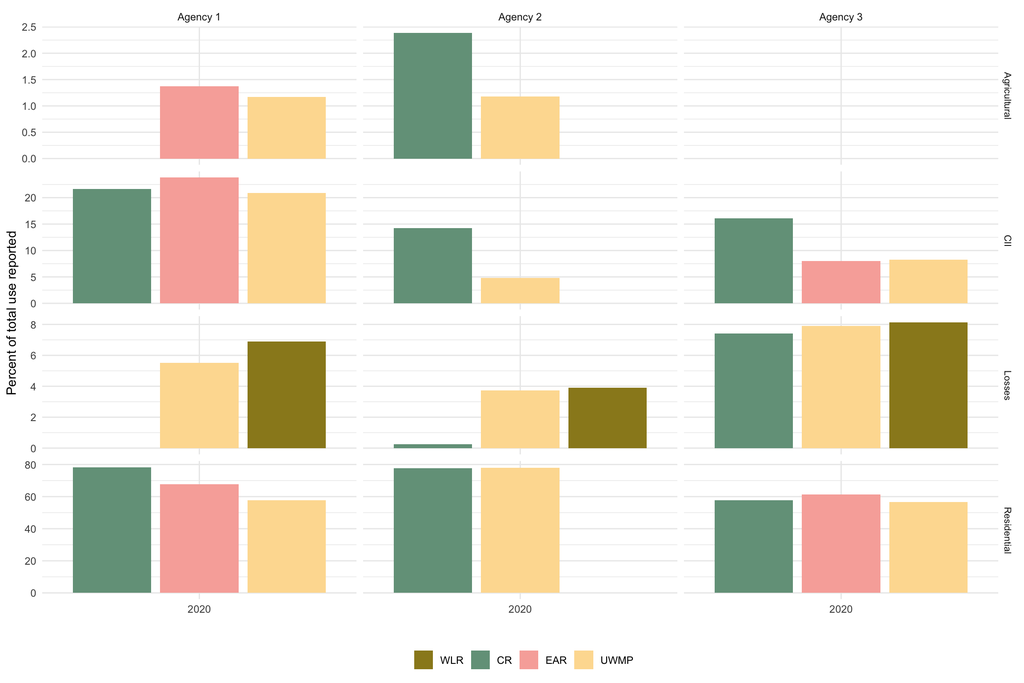

Figure 1. Percent of total water use reported by water use category (only those reported on the CR) compared across the CR, UWMP, EAR, and WLR for three agencies.

This suggests that for some suppliers data reported on the CR represents an estimate rather than actual volumes. This characteristic distinguishes the CR from the UWMP, EAR, and WLR.

The disconnect between state reporting requirements and the reality of local supplier data collection and analysis methods extends beyond the CR. For instance, one supplier discussed the timing expectations of the upcoming Annual Water Supply and Demand Assessment:

*“Now have the Annual Water Supply and Demand Assessment Reporting requirement, right. This was happening July 1st and and they assume that every district does it the same way, you know, we’re all gonna know our projection end of June or all this for the next year and stuff. And we don’t do it that way.”*

## Definitional inconsistency

Similar information is reported across reports; however, there are some distinct differences in how information is reported. Recycled water, for instance, is reported differently across reports.

Figure 3 compares water supply by use category (see the data mapping tab for more details on categories) across reports for Agency 3 and Figure 4 compares water demand by use category for Agency 3. Recycled water accounts for some of the differences across reports because it is not reported for the WLR or CR. Agency 3 reports recycled water use as an Other use on the EAR (Figure 3).

One of the primary reasons values may differ across reports is the reporting timeline may differ. The EAR is reported on an annual basis whereas the UWMP and WLR is reported as a fiscal year and the CR is reported monthly.

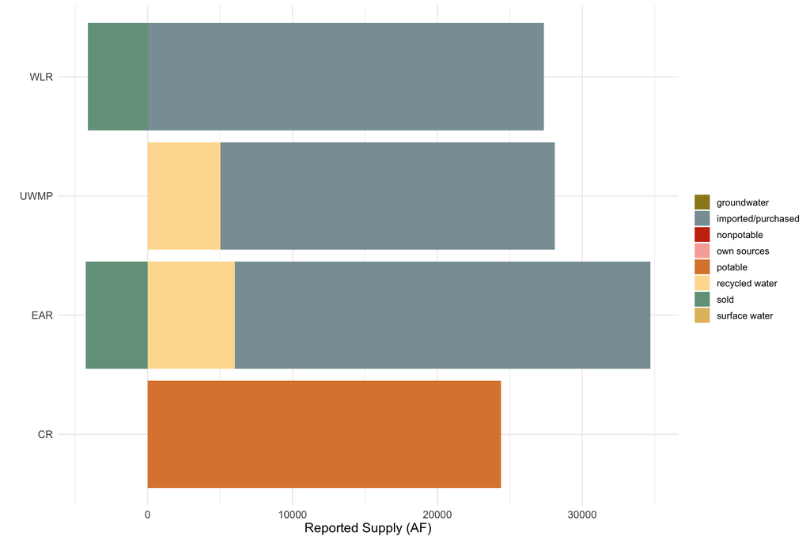

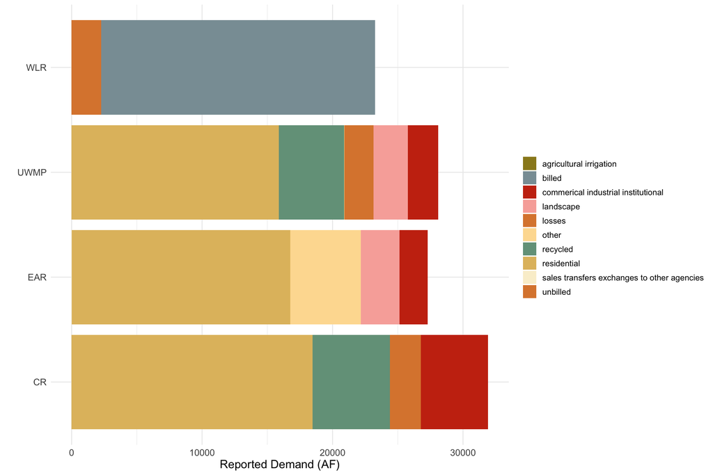